# EDA_MICali

Jhon Alexander Rojas Tavera

2023-08-13

# Informe Unidad I, Analisis exploratorio de datos

## 1. Introducción

El análisis del mercado inmobiliario es una herramienta crucial para comprender la dinámica y las tendencias que impactan en el sector de bienes raíces. En este informe, se abordará el análisis del mercado inmobiliario en Cali, Colombia, utilizando datos recopilados por la empresa B&C (Bienes y Casas), una agencia de bienes raíces de renombre en la ciudad.

Cali, una ciudad en constante evolución, ha sido testigo de un crecimiento sustancial en el mercado inmobiliario en los últimos años. Este crecimiento está impulsado por diversos factores, como el aumento de la población, la inversión extranjera directa y la construcción de nuevos proyectos residenciales. Con el propósito de aprovechar este entorno dinámico, la empresa B&C ha recopilado y sistematizado una vasta cantidad de datos sobre viviendas en Cali, que incluyen información sobre precios, ubicaciones, características y detalles de ventas.

Este informe tiene como objetivo explorar y analizar estos datos con el fin de identificar tendencias y patrones significativos que puedan servir como base para la toma de decisiones estratégicas por parte de la empresa B&C. A través de un enfoque descriptivo y analítico, se espera brindar una visión completa y precisa del mercado inmobiliario en Cali, permitiendo a la empresa tomar medidas informadas para su crecimiento y éxito continuo.

El informe está estructurado en varios apartados, que incluyen objetivos, métodos utilizados, resultados obtenidos, discusión de los hallazgos, conclusiones y anexos. Cada sección proporcionará una perspectiva detallada y significativa para comprender mejor la dinámica del mercado inmobiliario en Cali.

## 2. Objetivos

En este apartado se descibren los objetivos que se pretenden alcanzar de acuerdo a los criterios de entrega de la actividad y en concordancia con el caso de estudio propuesto.

- Objetivo general:

Realizar un analisis explotario de datos EDA, que permita a la empresa B&C tomar decisiones sobre su negocio

- Objetivo especifico 1:

Realizar analisis descriptivo de los datos recibidos, *vivienda_faltantes*

- Especifico 2:

identificar las tendencias y patrones de los datos recibidos, *vivienda_faltantes*

## 3. Métodos

Lectura de la base de datos desde archivo CSV, en mi caso la hice mediante el uso del fichero remitido por la profesora denominado “vivienda_faltantes.csv”, con las siguientes acciones en RStudio: File, Import DataSet, From Text(readr) y el nombre del archivo se paso como atributo a la variable “Baseviviendas”:

Lectura del dataset desde (readr) y se asigno a una variable, se muestra la cabecera de los datos:

```
## # A tibble: 6 × 13
##      id zona        piso estrato preciom areaconst parquea banios habitac tipo
##   <dbl> <chr>      <dbl>   <dbl>   <dbl>     <dbl>   <dbl>  <dbl>   <dbl> <chr>
## 1  8312 Zona Oeste     4       6    1300       318       2      4       2 Apart…
## 2  8311 Zona Oeste     1       6     480       300       1      4       4 Casa
## 3  8307 Zona Oeste    NA       5    1200       800       4      7       5 Casa
## 4  8296 Zona Sur       2       3     220       150       1      2       4 Casa
## 5  8297 Zona Oeste    NA       5     330       112       2      4       3 Casa
## 6  8298 Zona Sur      NA       5    1350       390       8     10      10 Casa
## # ℹ 3 more variables: barrio <chr>, longitud <dbl>, latitud <dbl>
```

Utilice la función summary para obtener los estadisticos básicos y estos son asignados a una variables para su visualiazación:

```
##        id           zona                piso           estrato
##  Min.   :   1   Length:8330        Min.   : 1.000   Min.   :3.000
##  1st Qu.:2082   Class :character   1st Qu.: 2.000   1st Qu.:4.000
##  Median :4164   Mode  :character   Median : 3.000   Median :5.000
##  Mean   :4164                      Mean   : 3.772   Mean   :4.634
##  3rd Qu.:6246                      3rd Qu.: 5.000   3rd Qu.:5.000
##  Max.   :8319                      Max.   :12.000   Max.   :6.000
##  NA's   :3                         NA's   :2641     NA's   :3
##     preciom         areaconst       parquea           banios
##  Min.   :  58.0   Min.   :  30   Min.   : 1.000   Min.   : 0.000
##  1st Qu.: 220.0   1st Qu.:  80   1st Qu.: 1.000   1st Qu.: 2.000
##  Median : 330.0   Median : 123   Median : 2.000   Median : 3.000
##  Mean   : 434.2   Mean   : 175   Mean   : 1.836   Mean   : 3.112
##  3rd Qu.: 540.0   3rd Qu.: 229   3rd Qu.: 2.000   3rd Qu.: 4.000
##  Max.   :1999.0   Max.   :1745   Max.   :10.000   Max.   :10.000
##  NA's   :2        NA's   :3      NA's   :1606     NA's   :3
##     habitac           tipo              barrio             longitud
##  Min.   : 0.000   Length:8330        Length:8330        Min.   :-76576.00
##  1st Qu.: 3.000   Class :character   Class :character   1st Qu.:-76506.00
##  Median : 3.000   Mode  :character   Mode  :character   Median :   -76.54
##  Mean   : 3.605                                         Mean   :-21845.13
##  3rd Qu.: 4.000                                         3rd Qu.:   -76.52
##  Max.   :10.000                                         Max.   :   -76.46
##  NA's   :3                                              NA's   :3
##     latitud
##  Min.   :   3.333
##  1st Qu.:   3.390
##  Median :   3.450
##  Mean   : 970.370
##  3rd Qu.:3367.000
##  Max.   :3497.000
##  NA's   :3
```

Para identificar Filtrar los datos para mostrar solo las primeras 10 filas y las columnas ‘precio’ y ‘zona’, luego mostrar el conjunto de datos filtrado:

```
## # A tibble: 10 × 2
##    preciom zona
##      <dbl> <chr>
##  1    1300 Zona Oeste
##  2     480 Zona Oeste
##  3    1200 Zona Oeste
##  4     220 Zona Sur
##  5     330 Zona Oeste
##  6    1350 Zona Sur
##  7     305 Zona Sur
##  8     480 Zona Oeste
##  9     275 Zona Sur
## 10     285 Zona Sur
```

En este apartado se pretende mostrar si existe relación mediante un gráfico de dispersión entre ‘areaconst’ y ‘preciom’

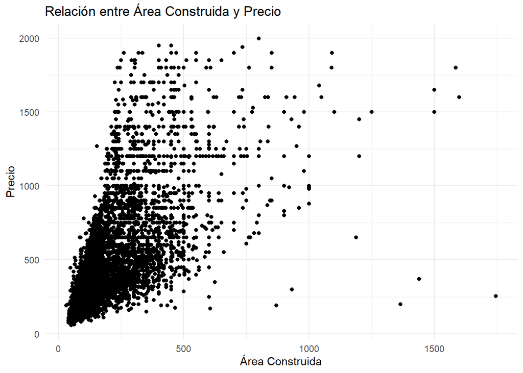

En este Gráfico de Dispersión se incluyó una tercer variable categorica no numerica Zona con Color en este caso los valores NA se eliminan y el resultado obtenido guarda concordancia con el resultado inmediatamente anterior.

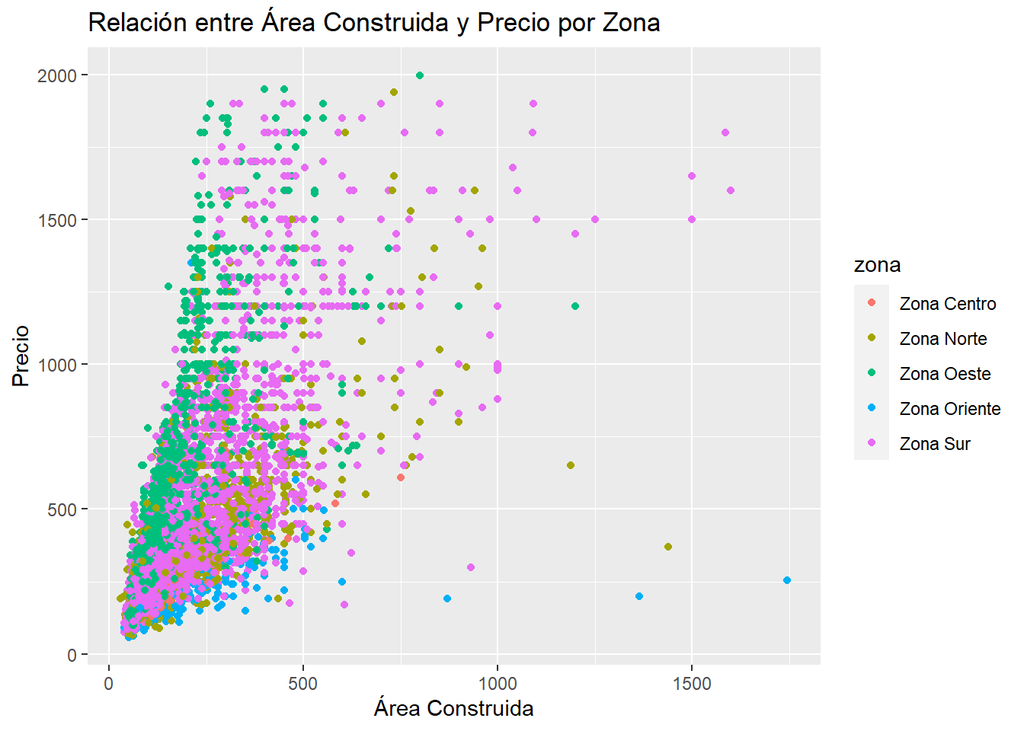

```r
Baseviviendas_faltantes <- colSums(is.na(Baseviviendas))

# Mostrar la cantidad de valores faltantes
Baseviviendas_faltantes
```

```
##        id      zona      piso   estrato   preciom areaconst   parquea    banios
##         3         3      2641         3         2         3      1606         3
##   habitac      tipo    barrio  longitud   latitud
##         3         3         3         3         3
```

Histograma de Precios:

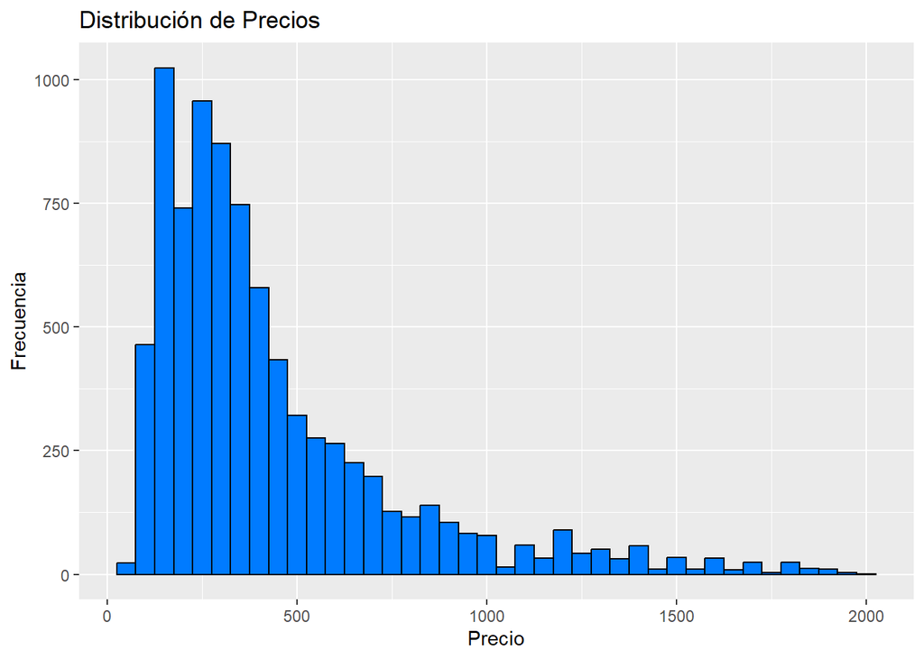

Boxplot de Precios por Zona (sin valores NA)

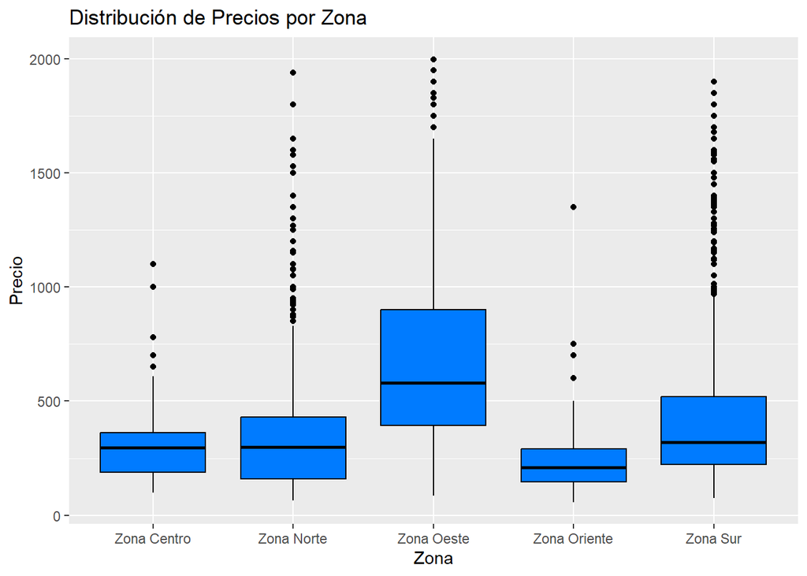

Analisis de Matriz de correlación

[figure not shown]

Crear un gráfico de barras para mostrar el tipo de viviendas con más stock

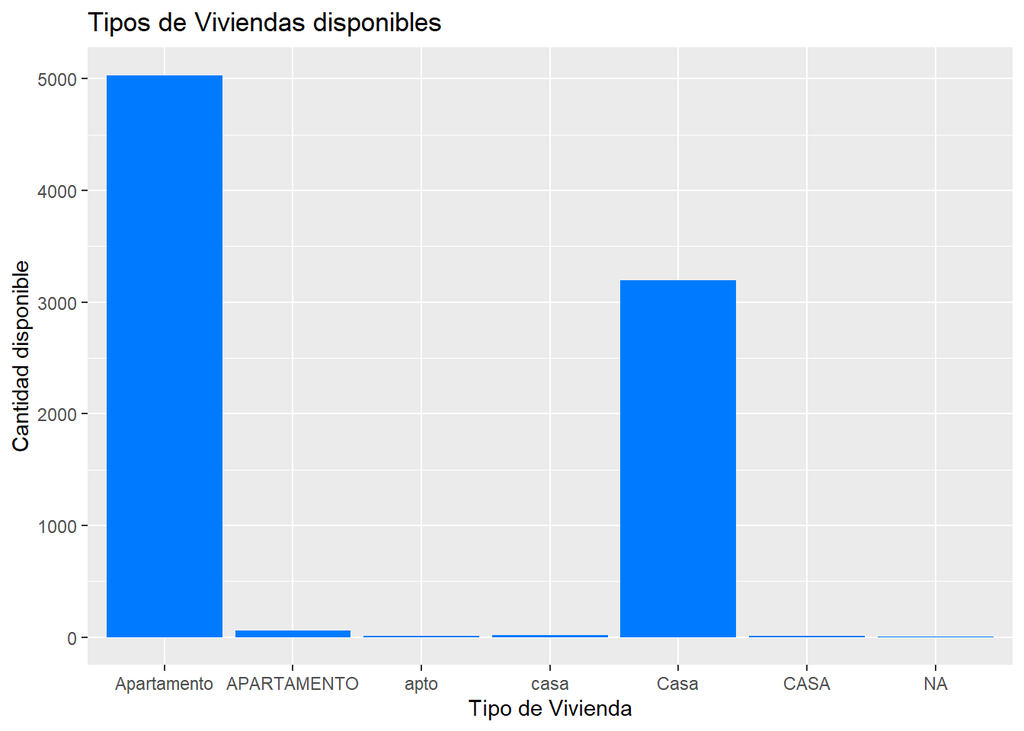

## 4. Resultados

En esta sección, con respecto al objetivo de la guía, se observa una desconexión con la actividad planteada. Aunque el caso se centra en el análisis de mercado, la validación de los datos en la base de datos “viviendas_faltantes” sugiere que estos registros corresponden a propiedades que no han sido objeto de gestión comercial, es decir, bienes que no han sido destinados a actividades comerciales.

Al analizar el caso, se plantea la identificación de un nicho de mercado, el desarrollo de estrategias de marketing, la fijación de precios de venta y la provisión de servicios personalizados a los clientes. Por consiguiente, se esperaba encontrar una capa de información que incluyera, al menos, fechas de venta, precios de venta ofrecidos y la identificación de posibles descuentos. La ausencia de estos datos genera un nivel de subjetividad considerable en las conclusiones que se pueden obtener.

Es importante destacar que la carencia de información relevante, como fechas de venta y detalles sobre los precios ofertados y los descuentos aplicados, limita la capacidad de realizar un análisis completo y preciso. Esto podría dificultar la formulación de conclusiones sólidas y bien fundamentadas en relación con los objetivos planteados. Por lo tanto, es necesario abordar esta limitación para garantizar que las conclusiones extraídas sean respaldadas de manera objetiva por la información disponible.

## 5. Discusión

De acuerdo a instrucción de la profesora no se realiza.

## 6. Conclusiones

La actividad que llevé a cabo me proporcionó un valioso acercamiento a la herramienta RStudio. En mi caso particular, carecía de conocimientos previos sobre esta herramienta, y en mi entorno laboral no tengo la oportunidad de aplicar procesos estadísticos, a excepción del uso de herramientas de ofimática para representar información a través de tablas dinámicas basadas en la lógica del negocio.

Es importante señalar que el material de revisión disponible en Brightspace no me brindó una guía clara para abordar este punto de partida, especialmente para aquellos de nosotros que no teníamos familiaridad con esta herramienta. No obstante, gracias a la instrucción del tablero proporcionado por la profesora y a la búsqueda de recursos en forma de video tutoriales en otras plataformas, logré completar exitosamente esta tarea. Sin embargo, reconozco que existe margen para la mejora, y me comprometo a enfocarme en fortalecer la calidad y el impacto de mis futuros trabajos.

En resumen, esta experiencia me permitió adquirir destrezas significativas en el uso de RStudio y superar desafíos relacionados con la falta de conocimiento previo. Considero que esta adquisición será de gran utilidad en mi trayectoria académica y profesional, permitiéndome realizar análisis estadísticos con mayor confianza y eficacia, a la vez que trabajaré en mejorar la calidad de mis entregas en futuros proyectos.

## 7. Anexos

Si deseas acceder al código fuente utilizado en la realización de este proyecto, así como a los archivos generados dentro de su carpeta respectiva, te invito a consultar el siguiente repositorio en GitHub:

https://github.com/Jartpuro/InformeEDA.git